# Matplotlib

### Matplotlib

Matplotlib is one of the most popular Python libraries for creating static, animated, and interactive visualizations in a variety of formats. It is particularly useful for data visualization in scientific and analytical fields. The core object of Matplotlib is its pyplot module, which provides a MATLAB-like interface for creating plots.

Matplotlib is often used with other libraries such as NumPy and Pandas to visualize data effectively. Some of the common types of plots you can create using Matplotlib include line plots, bar charts, histograms, scatter plots, pie charts, and more.

Basic Plotting

```
Matplotlib’s pyplot interface allows you to quickly create basic plots like line plots, scatter plots, and histograms.
```

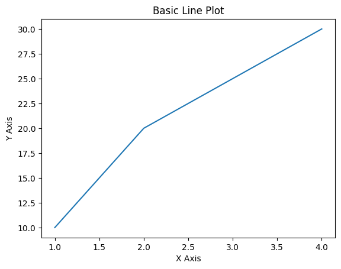

```python
import matplotlib.pyplot as plt

# Basic Line Plot
x = [1, 2, 3, 4]
y = [10, 20, 25, 30]

plt.plot(x, y)
plt.xlabel('X Axis')
plt.ylabel('Y Axis')
plt.title('Basic Line Plot')
plt.show()
```

Figure and Axes

```
In Matplotlib, a figure is the overall window where plots are drawn, and an axes is an individual plot or graph inside the figure. A figure can contain multiple axes (or subplots).
```

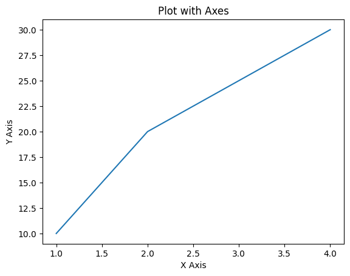

```python
fig, ax = plt.subplots()  # Creates a figure and a single axes
ax.plot(x, y)
ax.set_xlabel('X Axis')
ax.set_ylabel('Y Axis')
ax.set_title('Plot with Axes')
```

Customizing Plots

```
Matplotlib provides a vast range of options to customize the appearance of plots:

Colors: Set the line or marker color
```

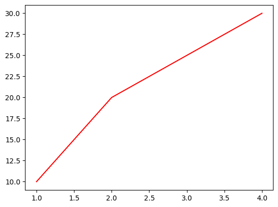

```python
plt.plot(x, y, color='red')
```

```
Line Styles: Change the line style using options like '-', '--', '-.'
```

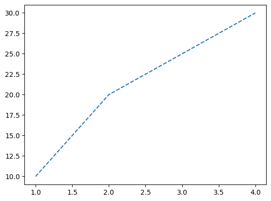

```python
plt.plot(x, y, linestyle='--')
```

```
Markers: Change the markers for points using options like 'o', '*', 'x'.
```

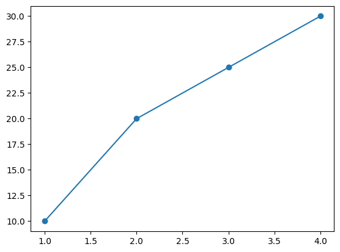

```python
plt.plot(x, y, marker='o')
```

Subplots

```
You can create multiple plots (subplots) in a single figure:
```

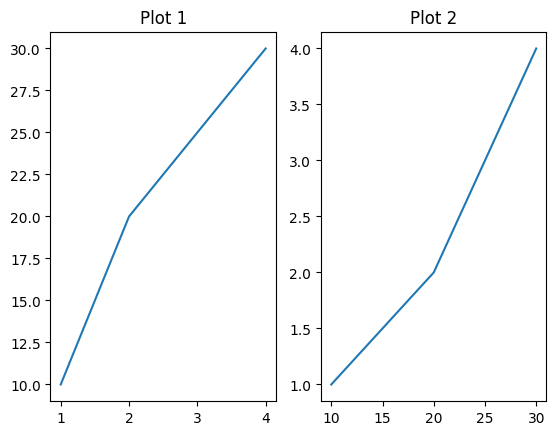

```python
fig, (ax1, ax2) = plt.subplots(1, 2)  # 1 row, 2 columns
ax1.plot(x, y)
ax1.set_title('Plot 1')

ax2.plot(y, x)
ax2.set_title('Plot 2')
plt.show()
```

Adding Labels, Titles, and Legends

```
Matplotlib allows you to add labels, titles, and legends to your plot:

Title: Add a title to the plot.
```

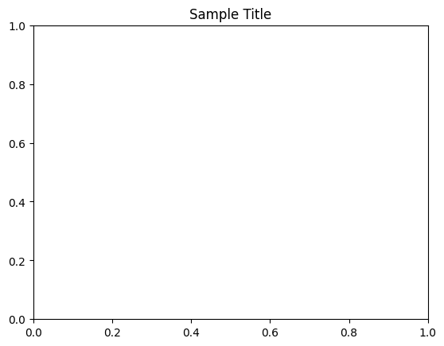

```python
plt.title('Sample Title')
```

```
Labels: Label the x-axis and y-axis.
```

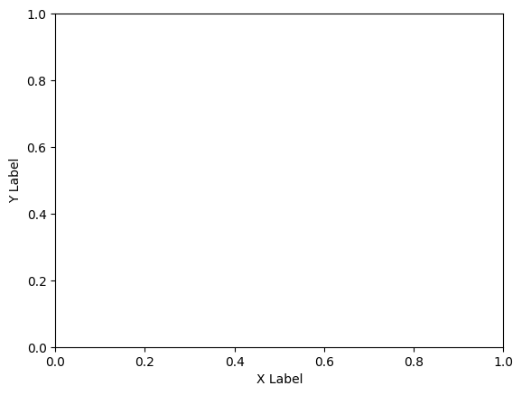

```python
plt.xlabel('X Label')
plt.ylabel('Y Label')
```

```
Legend: Add a legend to the plot to differentiate between multiple lines or data points.
```

[figure not shown]

```python
plt.legend(['Line 1', 'Line 2'])
```

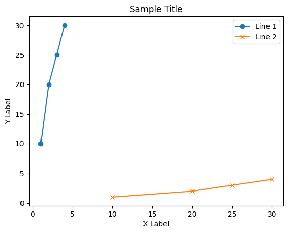

```python
plt.plot(x, y, marker='o')
plt.plot(y, x, marker='x')
plt.title('Sample Title')
plt.xlabel('X Label')
plt.ylabel('Y Label')
plt.legend(['Line 1', 'Line 2'])
plt.show()
```

Working with Grid and Ticks

```
You can easily enable grids in your plot to improve readability.
```

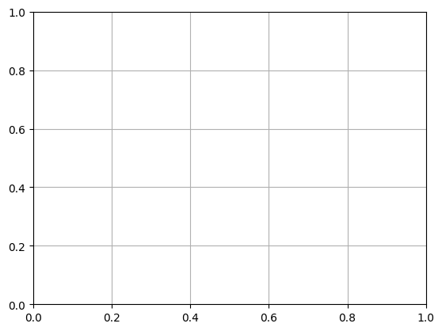

```python
plt.grid(True)
```

```
You can also customize ticks (major and minor ticks) to control the scales on the x-axis and y-axis.
```

[output not shown]

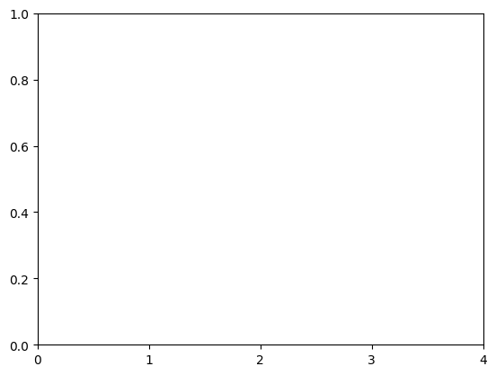

```python
plt.xticks([0, 1, 2, 3, 4])
```

Plot Types

```
Matplotlib supports various plot types beyond simple line plots

Scatter Plot
```

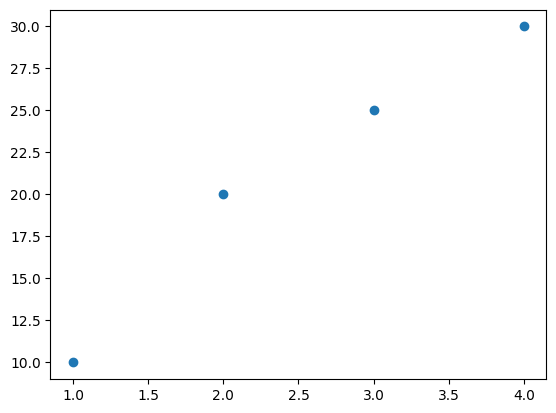

```python
plt.scatter(x, y)
```

```
Bar Plot
```

```
<BarContainer object of 4 artists>
```

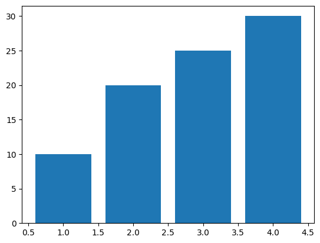

```python
plt.bar(x, y)
```

```
Histogram
```

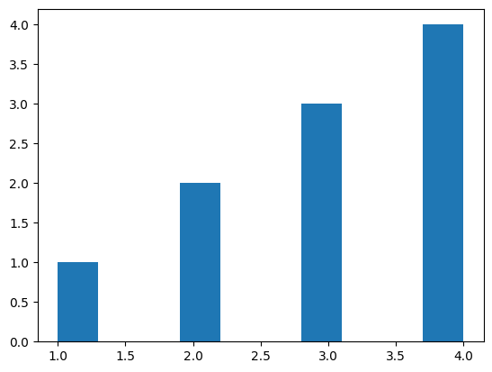

```python
data = [1, 2, 2, 3, 3, 3, 4, 4, 4, 4]
plt.hist(data)
```

```
Pie Chart
```

[output not shown]

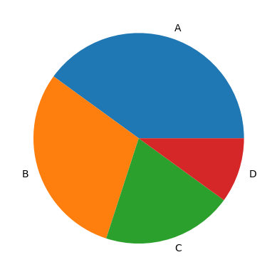

```python
sizes = [40, 30, 20, 10]
labels = ['A', 'B', 'C', 'D']
plt.pie(sizes, labels=labels)
```

Handling Dates

```
Matplotlib works seamlessly with date and time data using the dates module
```

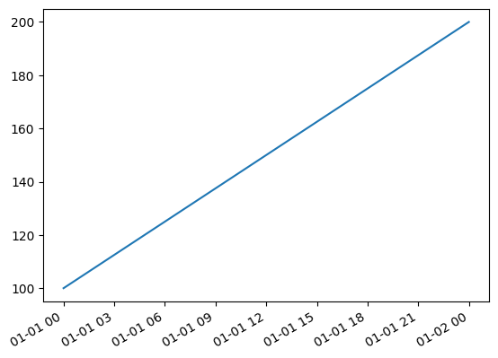

```python
import matplotlib.dates as mdates
import datetime as dt

dates = [dt.datetime(2024, 1, 1), dt.datetime(2024, 1, 2)]
values = [100, 200]

plt.plot(dates, values)
plt.gcf().autofmt_xdate()  # Auto formats the dates on x-axis
```

Saving Figures

```
After generating a plot, you can save the figure to a file in various formats such as PNG, PDF, or SVG.
```

```python
plt.savefig('my_plot.png')
```

Interactive Plots

```
Matplotlib integrates with Jupyter Notebooks and other interactive environments to create interactive plots. By using %matplotlib inline, you can display plots inline in Jupyter notebooks.
```

3D Plots

```
Matplotlib can generate 3D plots using mpl_toolkits.mplot3d.
```

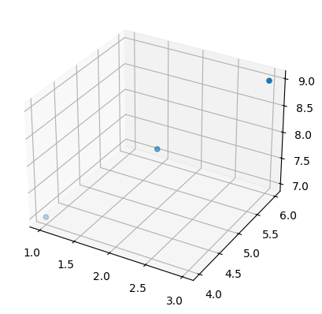

```python
from mpl_toolkits.mplot3d import Axes3D
fig = plt.figure()
ax = fig.add_subplot(111, projection='3d')
ax.scatter([1, 2, 3], [4, 5, 6], [7, 8, 9])
```

Data Visualization:

```
It is the representation of data in a pictorial or graphical format.
Allows the decision makers to see analytics, grasp difficult concepts and identify new patterns at ease.
```

Anscombe's quartet:

```
It comprises four datasets that have nearly identical simple descriptive statistics, yet appear very difficult when graphed.
If we take the data in statistics representation, all the mean, median, standard deviation like multiple factors looks same.
But graphical points are plotted in different pattern.
```

Libraries:

```
Matplotlib, seaborn, ggplot, plotly, geoplotlib
```

Matplotlib:

```
Python library for Data Visualization.
Create 2D graphs and plots using python scripts.
Produces output in a variety of hardcopy formats.
provides a module called Pyplot.
simple functions used for Visualization.
supports a very wide variety of graphs.
Easy integration with Pandas and Numpy.
Provides an Object-Oriented API.
```

Types of Plots:

```
Line, Bar, Scatter, Histogram, Image, Box, Violin, Stream, Quiver, Area, Pie and Donut.
```

```
Import libraries, matplotlib.pyplot as plt.
x and y are input and output list.
```

Line Plot:

[output not shown]

Bar Plot:

```
simple bar plot:
    plt.bar(x,y)
    plt.show()

Customize line plot:
    plt.bar(x, y, color="r")
    plt.title('Title Name')
    plt.xlabel('xlabel name')
    plt.ylabel('ylabel name')
    plt.grid(True)
    plt.show()
    # color = color of plotted line
    # if we need horizontal bar graph
    plt.barh(x, y)
    plt.show()
```

Scatter Plot:

```
Simple Scatter plot:
    plt.scatter(x, y)
    plt.show()

Multiple scatter plots:
    plt.scatter(x, y)
    plt.scatter(x, z)
    plt.legend(['y','z'], loc='best')
    plt.show()

Customize scatter plot:
    plt.scatter(x, y, c='g', s=300, edgecolors='y', marker='o', alpha=0.5)
    plt.scatter(x, z, c='r', s=400, edgecolors='b', marker='4', alpha=1)
    plt.legend(['y','z'], loc='best')
    plt.title('Title Name')
    plt.xlabel('xlabel name')
    plt.ylabel('ylabel name')
    plt.grid(True)
    plt.show()
    # c = color of plotted points
    # s = size of plotted points
    # edgecolors = color of edge points
    # marker = points in graph
    # alpha = opacity of plotted points
```

Histogram:

```
Simple Histogram:
    plt.hist(x, bins=[limit])
    plt.show()
    # limit means range of each x values
    # x means list of numbers

Customize Histogram:
    plt.hist(x, bins=[limit], color='r', edgecolor='b')
    plt.title('Title Name')
    plt.xlabel('xlabel name')
    plt.ylabel('ylabel name')
    plt.grid(True)
    plt.savefig('name.png')
    plt.show()
```

Box Plot:

```
Simple Box plot:
    plt.boxplot(x)
    plt.show()
    # x means list of numbers

Customize Box plot:
    plt.boxplot(x, showmeans=True)
    plt.title('Title Name')
    plt.xlabel('xlabel name')
    plt.ylabel('ylabel name')
    plt.grid(True)
    plt.show()
```

Violin Plot:

```
Simple Violin plot:
    plt.violinplot(x)
    plt.show()
    # x means list of numbers

Customize Violin plot:
    plt.violinplot(x)
    plt.title('Title Name')
    plt.xlabel('xlabel name')
    plt.ylabel('ylabel name')
    plt.grid(True)
    plt.show()
```

Pie Chart:

```
Simple Pie chart:
    plt.pie(x, labels=y)
    plt.show()
    # x means list of values
    # y means list of labels

Customize pie chart:
    plt.pie(x, labels=y, autopct='%1.1f%%', shadow=True, startangle=90)
    plt.title('Title Name')
    plt.xlabel('xlabel name')
    plt.ylabel('ylabel name')
    plt.show()
```

Donut chart:

```
Simple Donut chart:
    plt.pie(x, labels=y, radius=1.5)
    plt.pie(size_center, radius=1.0, colors='w')
    plt.show()
    # x means list of numbers
    # y means list of labels
    # size_center means space in center

Customize Donut chart:
    a,b,c = [plt.cm.Blues,plt.cm.Reds,plt.cm.Greens]
    plt.pie(x, labels=y, radius=1.5, colors=[a(0.5),b(1.5),c(1.0)])
    plt.pie(size_center, radius=1.0, colors='w')
    plt.show()
```

Area chart:

```
Simple Area chart:
    plt.stackplot(x,y)
    plt.show()
    # x means list of numbers
    # y means list of numbers

Customize Area chart:
    plt.stackplot(x,y,colors='Black', alpha=0.5)
    plt.title('Title Name')
    plt.xlabel('xlabel name')
    plt.ylabel('ylabel name')
    plt.show()

merging area chart with line chart
    plt.stackplot(x,y,colors='Black', alpha=0.5)
    plt.plot(x,y,colors='g')
    plt.show()
```

To save any plots:

```
plt.savefig('name.png')
```

Possible Interview Questions on Matplotlib

1. What is Matplotlib, and why is it used?

   ```
    Matplotlib is a Python library for creating static, interactive, and animated visualizations. It provides an easy-to-use interface for plotting data and is widely used in data science for visualizing datasets, exploring data, and presenting results.
   ```

2. What are the key objects in Matplotlib?

   ```
    The two key objects in Matplotlib are:
        Figure: The container for all plot elements.
        Axes: The area of the figure where the data is plotted (often called a subplot).
   ```

3. How do you create a basic line plot in Matplotlib?

   ```
    Answer: You can use plt.plot() to create a basic line plot.
   ```

4. How do you add a title, x-label, and y-label to a plot?

   ```
    plt.title('Title'): Adds a title to the plot.
    plt.xlabel('X Axis'): Labels the x-axis.
    plt.ylabel('Y Axis'): Labels the y-axis.
   ```

5. What is the difference between plt.plot() and plt.scatter()?

   ```
    plt.plot() is used for line plots where points are connected by lines, while plt.scatter() is used to create scatter plots where individual data points are plotted without lines.
   ```

6. How do you create multiple subplots in Matplotlib?

   ```
    You can use plt.subplots() to create multiple subplots in a figure.
   ```

7. How do you enable grid lines in a plot?

   ```
    You can use plt.grid(True) to enable grid lines on the plot.
   ```

8. How do you save a plot to a file in Matplotlib?

   ```
    You can save a plot using plt.savefig() to store the figure in a file format like PNG, PDF, or SVG.
   ```

9. What are some common types of plots you can create using Matplotlib?

   ```
    Some common types of plots include line plots, bar plots, scatter plots, histograms, pie charts, and 3D plots.
   ```

10. What is the use of plt.show() in Matplotlib?

    ```
    plt.show() is used to display the plot in a window or inline in a notebook. It renders the current figure and pauses the execution until the window is closed.
    ```

11. How can you customize the appearance of a plot in Matplotlib?

    ```
    You can customize the appearance of plots by adjusting colors, line styles, markers, adding legends, and configuring axes using various arguments in the plotting functions (color, linestyle, marker, etc.).
    ```

12. What is the purpose of fig, ax = plt.subplots() in Matplotlib?

    ```
    plt.subplots() is used to create a figure and one or more axes (subplots). This is useful for more complex plotting scenarios where you want to create multiple plots in a single figure.
    ```

### Reference

```
ChatGPT
```